# Machine Learning

Nikos Kouvoutsakis

25-7-2018

## Intro

*One thing that people regularly do is quantify how much of a particular activity they do, but they rarely quantify how well they do it. In this project, our goal will be to use data from accelerometers on the belt, forearm, arm, and dumbell of 6 participants. They were asked to perform barbell lifts correctly and incorrectly in 5 different ways.*

## Goal

*The goal of this project is to predict the manner in which they did the exercise. This is the “classe” variable in the training set. We use any of the other variables to predict with. We wll create a report describing how we built our model, how we used cross validation, what we think the expected out of sample error is, and why we made the choices we did. We will also use our prediction model to predict 20 different test cases.*

## Load needed packages and set defaults

```r
knitr::opts_chunk$set(echo=TRUE)
knitr::opts_knit$set(root.dir = "~/R_Programs")
library(GGally)
library(dplyr)
library(ggplot2)
library(gridExtra)
library(grid)
library(kableExtra)
library(knitr)
library(caret)
library(rattle)
library(rpart)
library(rpart.plot)
library(RColorBrewer)
library(rattle)
library(randomForest)
library(doParallel)
library(lda)
```

*Create Project’s folder in working directory*

```r
if(!file.exists("./Machine.learning")){
dir.create("./Machine.learning")
}
```

## Data Processing

### 1.Loading project’s data

*Download files if not exist and Load data*

```r
if(!file.exists("./Machine.learning/TrainingData.csv")){
fileUrl <- "https://d396qusza40orc.cloudfront.net/predmachlearn/pml-training.csv"
download.file(fileUrl, destfile = "./Machine.learning/TrainingData.csv")
TrainingData<-read.csv("./Machine.learning/TrainingData.csv")
}else{
TrainingData<-read.csv("./Machine.learning/TrainingData.csv")
}

if(!file.exists("./Machine.learning/ValidationData.csv")){
fileUrl <- "https://d396qusza40orc.cloudfront.net/predmachlearn/pml-testing.csv"
download.file(fileUrl, destfile = "./Machine.learning/ValidationData.csv")
ValidationData<-read.csv("./Machine.learning/ValidationData.csv")
}else{
ValidationData<-read.csv("./Machine.learning/ValidationData.csv")
}

str(TrainingData)
```

```
## 'data.frame':    19622 obs. of  160 variables:
##  $ X                       : int  1 2 3 4 5 6 7 8 9 10 ...
##  $ user_name               : Factor w/ 6 levels "adelmo","carlitos",..: 2 2 2 2 2 2 2 2 2 2 ...
##  $ raw_timestamp_part_1    : int  1323084231 1323084231 1323084231 1323084232 1323084232 1323084232 1323084232 1323084232 1323084232 1323084232 ...
##  $ raw_timestamp_part_2    : int  788290 808298 820366 120339 196328 304277 368296 440390 484323 484434 ...
##  $ cvtd_timestamp          : Factor w/ 20 levels "02/12/2011 13:32",..: 9 9 9 9 9 9 9 9 9 9 ...
##  $ new_window              : Factor w/ 2 levels "no","yes": 1 1 1 1 1 1 1 1 1 1 ...
##  $ num_window              : int  11 11 11 12 12 12 12 12 12 12 ...
##  $ roll_belt               : num  1.41 1.41 1.42 1.48 1.48 1.45 1.42 1.42 1.43 1.45 ...
##  $ pitch_belt              : num  8.07 8.07 8.07 8.05 8.07 8.06 8.09 8.13 8.16 8.17 ...
##  $ yaw_belt                : num  -94.4 -94.4 -94.4 -94.4 -94.4 -94.4 -94.4 -94.4 -94.4 -94.4 ...
##  $ total_accel_belt        : int  3 3 3 3 3 3 3 3 3 3 ...
##  $ kurtosis_roll_belt      : Factor w/ 397 levels "","-0.016850",..: 1 1 1 1 1 1 1 1 1 1 ...
##  $ kurtosis_picth_belt     : Factor w/ 317 levels "","-0.021887",..: 1 1 1 1 1 1 1 1 1 1 ...
##  $ kurtosis_yaw_belt       : Factor w/ 2 levels "","#DIV/0!": 1 1 1 1 1 1 1 1 1 1 ...
```

[output cut: 86 more lines]

```r
str(ValidationData)
```

```
## 'data.frame':    20 obs. of  160 variables:
##  $ X                       : int  1 2 3 4 5 6 7 8 9 10 ...
##  $ user_name               : Factor w/ 6 levels "adelmo","carlitos",..: 6 5 5 1 4 5 5 5 2 3 ...
##  $ raw_timestamp_part_1    : int  1323095002 1322673067 1322673075 1322832789 1322489635 1322673149 1322673128 1322673076 1323084240 1322837822 ...
##  $ raw_timestamp_part_2    : int  868349 778725 342967 560311 814776 510661 766645 54671 916313 384285 ...
##  $ cvtd_timestamp          : Factor w/ 11 levels "02/12/2011 13:33",..: 5 10 10 1 6 11 11 10 3 2 ...
##  $ new_window              : Factor w/ 1 level "no": 1 1 1 1 1 1 1 1 1 1 ...
##  $ num_window              : int  74 431 439 194 235 504 485 440 323 664 ...
##  $ roll_belt               : num  123 1.02 0.87 125 1.35 -5.92 1.2 0.43 0.93 114 ...
##  $ pitch_belt              : num  27 4.87 1.82 -41.6 3.33 1.59 4.44 4.15 6.72 22.4 ...
##  $ yaw_belt                : num  -4.75 -88.9 -88.5 162 -88.6 -87.7 -87.3 -88.5 -93.7 -13.1 ...
##  $ total_accel_belt        : int  20 4 5 17 3 4 4 4 4 18 ...
##  $ kurtosis_roll_belt      : logi  NA NA NA NA NA NA ...
##  $ kurtosis_picth_belt     : logi  NA NA NA NA NA NA ...
##  $ kurtosis_yaw_belt       : logi  NA NA NA NA NA NA ...
```

[output cut: 86 more lines]

### 2.Data cleaning and preprocess

- Remove first 7 variables since they only provide us with information on persons which carried the tests.
- Removing Columns with more than 80% of NAs or Blank values.
- Removing nearZero variables
- Keep common Variables in both Training and Validation Datasets.

All above actions are applied in both Training and Validation datasets.

```r
TrainingData<-TrainingData[,-c(1:7)]
TrainingData<-TrainingData[, -which(colSums(is.na(TrainingData) | TrainingData=="") > 0.8*nrow(TrainingData))]
ValidationData<-ValidationData[,-c(1:7)]
ValidationData<-ValidationData[, -which(colSums(is.na(ValidationData) | ValidationData=="") > 0.8*nrow(ValidationData))]

nzvTraining<-nearZeroVar(TrainingData,saveMetrics = TRUE)
nzvValidation<-nearZeroVar(ValidationData,saveMetrics = TRUE)

TrainingData<-TrainingData[,nzvTraining$nzv==FALSE]


ValidationData<-ValidationData[,nzvValidation$nzv==FALSE]

TrainingDataColum<-colnames(TrainingData)
ValidationDataColum<-colnames(ValidationData)


Allcolnames<-c(TrainingDataColum,ValidationDataColum)
Allcolnames<-data.frame(Allcolnames)
colnames(Allcolnames)<-c("col")
Allcolnames2<-as.data.frame(table(Allcolnames$col))

output<-Allcolnames2[Allcolnames2$Freq==2,]
unifcol<-as.vector(output$Var1)


TrainingDataUNI<-TrainingData[,unifcol]
TrainingDataUNI$classe<-TrainingData$classe

#str(TrainingDataUNI)
ValidationDataUNI<-ValidationData[,unifcol]
#str(ValidationDataUNI)
```

### 3.Split cleaned training data into a new Train and Test sets, providing their respective dimensions.

```r
set.seed(12345)
inTrain<-createDataPartition(y=TrainingDataUNI$classe,p=0.75,list=FALSE)

finalTrain<-TrainingDataUNI[inTrain,]
finalTest<-TrainingDataUNI[-inTrain,]
dim(finalTrain)
```

```
## [1] 14718    53
```

```r
dim(finalTest)
```

```
## [1] 4904   53
```

## Machine learning Algorithms

We will apply 4 differenct machine learning algorithms

- Classification Tree
- Linear Discriminant Analysis
- Random Forests
- Gradient Boosting method

and we will compare their respective results on the Train Set. (In Sample error) This will be a first indication on which model performs better.

### Algorithms application on Train Set

```r
set.seed(54321)
TC<-trainControl(method="cv",number=5)
modFitForest<-train(classe~.,data=finalTrain,method="rpart",trControl=TC)
predRpart<-predict(modFitForest,finalTest)
Accuracy.Tree<-confusionMatrix(finalTest$classe,predRpart)
```

```r
set.seed(54321)
modFitLDA<-train(classe~.,data=finalTrain,method="lda",trControl=trainControl(method="cv",number=5))
predLDA<-predict(modFitLDA,finalTest)
Accuracy.LDA<-confusionMatrix(finalTest$classe,predLDA)
```

```r
set.seed(54321)
no_cores <- detectCores()
cl <- makeCluster(no_cores)
registerDoParallel(cl)
modFitRForest<-train(classe~.,data=finalTrain,method="rf",trControl=TC)
stopCluster(cl)

predRF<-predict(modFitRForest,finalTest)
Accuracy.RForests<-confusionMatrix(finalTest$classe,predRF)
```

```r
set.seed(54321)
no_cores <- detectCores()
cl <- makeCluster(no_cores)
registerDoParallel(cl)
modFitGBM<-train(classe~.,data=finalTrain,method="gbm",trControl=TC, verbose=FALSE)
stopCluster(cl)

predGBM<-predict(modFitGBM,finalTest)
Accuracy.GBM<-confusionMatrix(finalTest$classe,predGBM)
```

### Models comparison (In Sample error)

```r
results <- resamples(list(Clas.Tree=modFitForest, LDA=modFitLDA, RForests=modFitRForest, GBM=modFitGBM ))
summary(results)[[3]][1]
```

```
## $Accuracy
##                Min.   1st Qu.    Median      Mean   3rd Qu.      Max. NA's
## Clas.Tree 0.5628397 0.5923913 0.5944935 0.5906374 0.5987088 0.6047538    0
## LDA       0.6925951 0.7015280 0.7037037 0.7034259 0.7055027 0.7138001    0
## RForests  0.9911715 0.9925272 0.9928620 0.9925263 0.9928668 0.9932042    0
## GBM       0.9578804 0.9609242 0.9612903 0.9616119 0.9639701 0.9639946    0
```

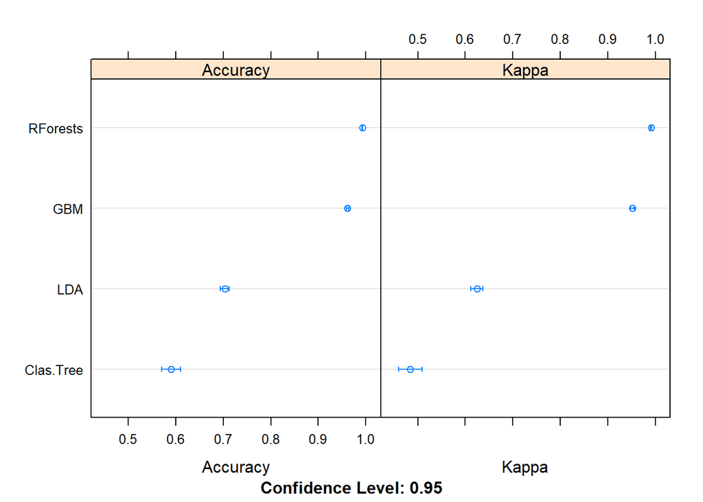

```r
dotplot(results)
```

### Algorithms application on Test set (Trees - Tables - Out Sample error)

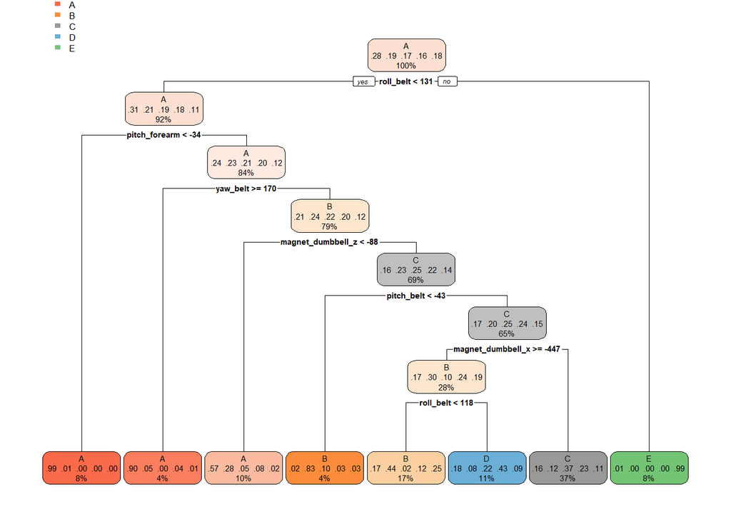

```r
rpart.plot(modFitForest$finalModel,roundint=FALSE)
```

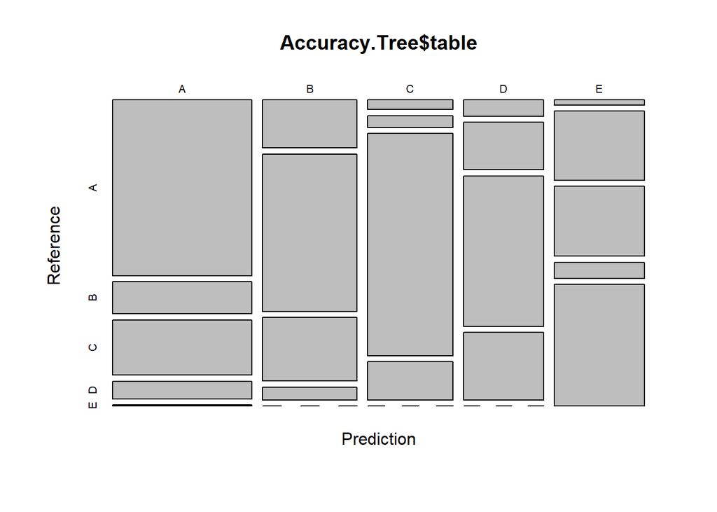

```r
plot(Accuracy.Tree$table)
```

```r
Accuracy.Tree$table
```

```
##           Reference
## Prediction   A   B   C   D   E
##          A 870 159 273  88   5
##          B 162 530 214  43   0
##          C  29  36 674 116   0
##          D  46 136 429 193   0
##          E  16 221 224  51 389
```

```r
Accuracy.Tree$overall[1]
```

```
##  Accuracy
## 0.5415987
```

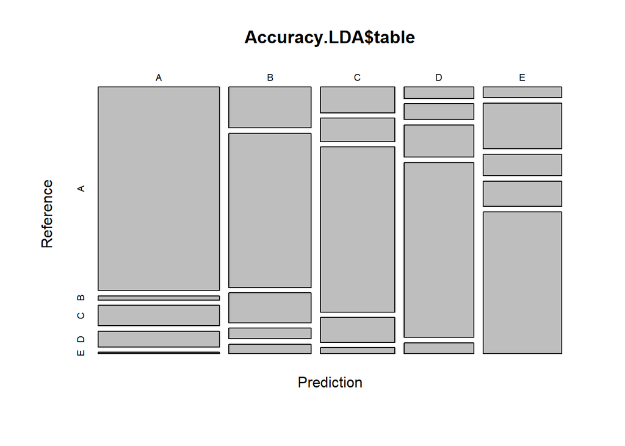

```r
plot(Accuracy.LDA$table)
```

```r
Accuracy.LDA$table
```

```
##           Reference
## Prediction    A    B    C    D    E
##          A 1157   24  116   90    8
##          B  158  597  116   41   37
##          C   90   82  575   87   21
##          D   37   52  106  573   36
##          E   39  168   80   93  521
```

```r
Accuracy.LDA$overall[1]
```

```
##  Accuracy
## 0.6980016
```

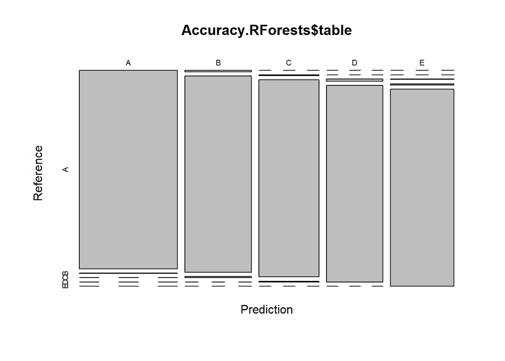

```r
plot(Accuracy.RForests$table)
```

```r
Accuracy.RForests$table
```

```
##           Reference
## Prediction    A    B    C    D    E
##          A 1394    1    0    0    0
##          B    6  938    5    0    0
##          C    0    3  849    3    0
##          D    0    0    8  796    0
##          E    0    0    2    5  894
```

```r
Accuracy.RForests$overall[1]
```

```
##  Accuracy
## 0.9932708
```

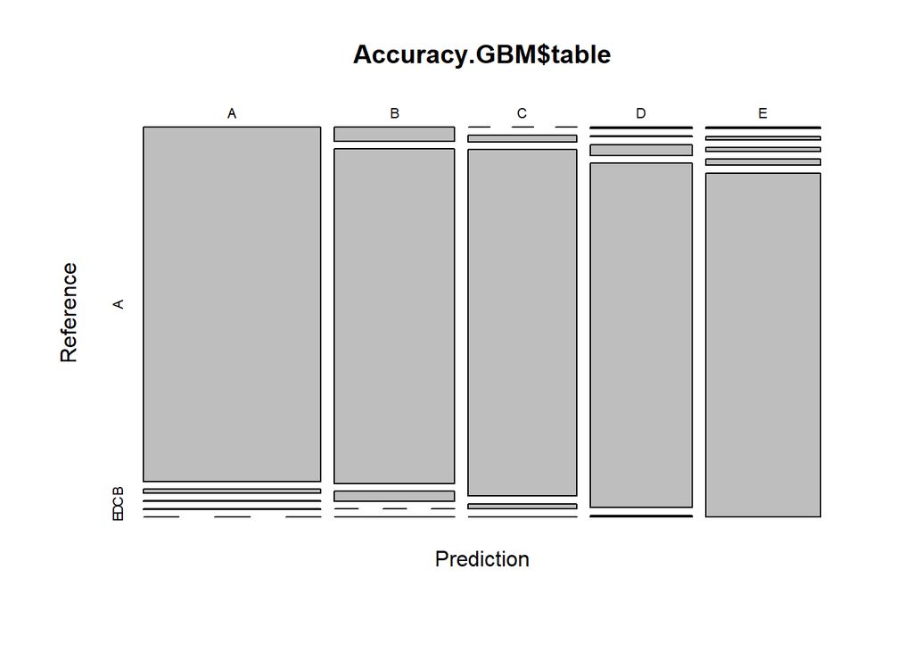

```r
plot(Accuracy.GBM$table)
```

```r
Accuracy.GBM$table
```

```
##           Reference
## Prediction    A    B    C    D    E
##          A 1377   15    2    1    0
##          B   37  885   26    0    1
##          C    0   16  826   12    1
##          D    2    2   24  772    4
##          E    3    9    9   16  864
```

```r
Accuracy.GBM$overall[1]
```

```
##  Accuracy
## 0.9632953
```

## Course Project Prediction Quiz Portion

Random Forests was classified as the best model to use. We will predict all 20 cases in Validation set by applying Random Forests algorithm.

```r
quiz<-predict(modFitRForest,newdata=ValidationDataUNI)
quiz
```

```
##  [1] B A B A A E D B A A B C B A E E A B B B
## Levels: A B C D E
```